# Barocco_Schirina

# Analysis on the dependency among stocks

These are the libraries we need.

```r
library(dplyr)
library(rvest)# web scraping
```

```r
library(tidyverse) # plot
library(boot) # bootstrapping
library(igraph) # graphs
library(energy) # distance correlation
library(GoFKernel)
require(foreach, quietly = TRUE)
require(doParallel, quietly = TRUE)
```

In this project we want to perform an analysis on the stocks we get from the *S&P500 index*. In particular we want to find out if the firms of the same sectors interact with each other, i.e. if they follow the same trend.

## Getting the dataset

We find all the informations we need on wikipedia site *“[https://en.wikipedia.org/wiki/List_of_S%26P_500_companies"*](https://en.wikipedia.org/wiki/List_of_S%26P_500_companies%22*). In particular we take *Symbol*, *Security*, *GICS Sector* and *GICS Sub Industry* and import it as a *tibble* dataframe.

```r
# we find the companies in wikipedia
sp_500_wiki <- read_html("https://en.wikipedia.org/wiki/List_of_S%26P_500_companies") %>%
  html_node("table.wikitable") %>%
  html_table() %>%
  select(`Symbol`, Security, `GICS Sector`, `GICS Sub Industry`) %>%
  as_tibble()
```

The next step is to retrieve the financial data from the *Yahoo! Finance* portal.

We want to perform the analysis on the relative prices whose formula was defined by Bordin starting from the closing price at a given day:

$x_{t,j} = log(\frac{c_{t,j}}{c_{t-1,j}})$

With these values we build the matrix $X_{hat} = [x_{t,j}]_{t,j}$ where $j$ is the index of the stock and $c_{j,t}$ is its closing price.

```r
SP500_index <- sp_500_wiki[[1]]

require(tseries, quietly = TRUE)

firm_vector <- c()

invisible(capture.output (for (firm in SP500_index) try({

  hist_quote = suppressWarnings(get.hist.quote(instrument = firm, start = "2003-01-01",
                                       end = "2008-01-01", quote = c("Open", "Close"),
                                       provider = "yahoo", drop = TRUE))

  hist_quote$trfm_price = diff(log(hist_quote$Close))

  assign(firm, hist_quote$trfm_price[-1,])

  firm_vector <- c(firm_vector, firm)
})))
```

[output not shown]

[output not shown]

In order to work with the correlation we check if there are some *Na* values: in this case we remove the entire column otherwise it could give some problems.

```r
merging <- lapply(firm_vector, get)
merge  = do.call('merge', merging)
names(merge) = firm_vector

# we remove the columns with some NA values
merge <- merge[ ,colSums(is.na(merge)) == 0]
```

## Getting the sample

We want to work with the companies and their corresponding *‘GICS sector’* so, applying the *group_by* function, we can take a sample of five companies per sector, thus we have *55* firms and *11* sectors: ‘Communication Service’, ‘Consumer Discretionary’, ‘Consumer Staples’, ‘Energy’, ‘Financials’, ‘Health Care’, ‘Industrials’, ‘Information Technology’, ‘Materials’, ‘Real Estate’, ‘Utilities’.

```r
set.seed(42);
samp_symbols <- sp_500_wiki[sp_500_wiki$Symbol %in% colnames(merge),] %>%
  # we want a sample of 5 companies for each sector
  group_by(`GICS Sector`) %>%
  sample_n(5) #%>%

samp_symbols
```

```
## # A tibble: 55 x 4
## # Groups:   GICS Sector [11]
##    Symbol Security          `GICS Sector`      `GICS Sub Industry`
##    <chr>  <chr>             <chr>              <chr>
##  1 VZ     Verizon Communic~ Communication Ser~ Integrated Telecommunicati~
##  2 DIS    The Walt Disney ~ Communication Ser~ Movies & Entertainment
##  3 CMCSA  Comcast Corp.     Communication Ser~ Cable & Satellite
##  4 TTWO   Take-Two Interac~ Communication Ser~ Interactive Home Entertain~
##  5 IPG    Interpublic Group Communication Ser~ Advertising
##  6 LOW    Lowe's Cos.       Consumer Discreti~ Home Improvement Retail
##  7 RL     Polo Ralph Laure~ Consumer Discreti~ Apparel, Accessories & Lux~
##  8 BWA    BorgWarner        Consumer Discreti~ Auto Parts & Equipment
##  9 MHK    Mohawk Industries Consumer Discreti~ Home Furnishings
## 10 NWL    Newell Brands     Consumer Discreti~ Housewares & Specialties
## # ... with 45 more rows
```

We can build the matrix *X_hat* with the time series on the rows and the companies on the columns.

```r
symbols <- samp_symbols$Symbol

X_hat <- merge[, symbols]
```

## Computing correlation matrix

Now we want to compute the correlation matrix of *X_{hat}*: we define a function that, given a matrix, returns the corresponding correlation matrix (calculated with *Pearson* method). To do this we use the built-in **cor** function that takes in input a matrix and returns the correlation one. Then we recall the *generate_corr_matr* on *X_{hat}* to get the *R_{hat}* matrix.

```r
R_hat = matrix(NA, nrow = 55, ncol = 55)

generate_corr_matr = function(X_hat, R_hat){

  R_hat = cor(X_hat)

return(R_hat)

}

R_hat = generate_corr_matr(X_hat, R_hat)
```

## Bootstrap procedure

Now we want to implement the bootstrap procedure on *X_{hat}* by (randomly) choosing rows from it. In order to make this process faster we decided to use the *foreach* parallelization scheme. We want *1000* replicates and again apply the *generate_corr_matr* function to get the correlation matrices. Finally we can compute the maximum of the distance $\Delta_b$ between *R_hat* and the boostraped replicates:

$\Delta_b = \sqrt{n} max|\hat{R}_b^*-\hat{R}|$

obtaining the *$\Delta_b$* vector.

```r
num_cores <- detectCores()

cl <- makeCluster(num_cores)

registerDoParallel(cl)

a <- Sys.time()

B = 1000 # number of replicates

delta_P = NULL

delta_P <- foreach(b = 1 : B, .combine=c) %dopar% {

  X_star <- matrix(NA, nrow = 1257, ncol = 55)

  idx = sample(1:1257, replace = TRUE)

  R_star =  matrix(NA, nrow = 55, ncol = 55 )

  for (i in 1:length(X_hat[,1])){

      X_star[i,] = X_hat[idx[i],] # bootstrap sample


  }

  R_star = generate_corr_matr(X_star, R_star)

  sqrt(1257) * max(abs(R_star - R_hat))

}

stopCluster(cl)
b <- Sys.time()

print(b-a)
```

```
## Time difference of 1.741924 secs
```

Let’s make a visualization of the *$\Delta_P$* vector *empirical cumulative distribution function*.

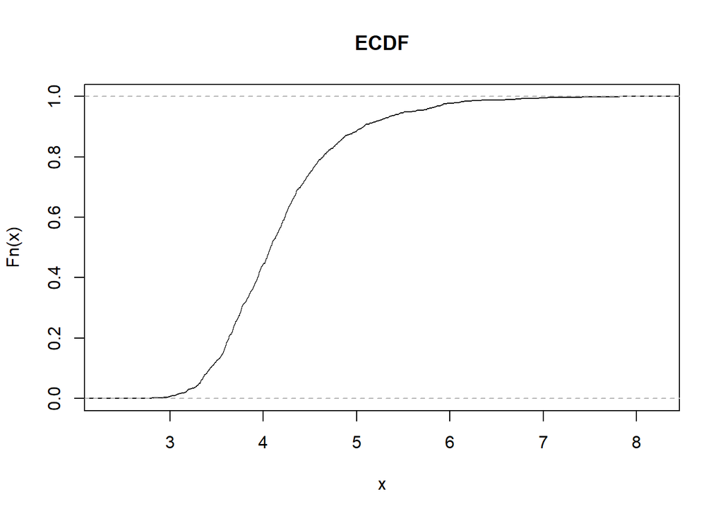

```r
# bootstrap ECDF
F_hat_P = ecdf(delta_P)

plot(F_hat_P, main = "ECDF")
```

## Plotting the graphs

Now we can build the adjacency matrix. In order to do this we take the confidence level to use its link with statistical tests: in detail the null hypothesis $H_0$ says that there is no edge {i,j} while the alternative one $H_1$ says that there’s and edge ${i,j}$.

```r
# confidence Level
alpha = 0.05

inv <- inverse(F_hat_P, 0, 25718774)
t_alpha <- inv(1-alpha)

t_alpha
```

```
## [1] 5.589204
```

```r
new_cor_matr  <- matrix(0, nrow = 55, ncol = 55)

generate_adj_matr = function(R_hat, t_alpha, epsilon){
  for (i in 1 : 55){
  for (j in 1 : 55){
    low <- R_hat[i,j] - t_alpha/sqrt(1257)
    up <- R_hat[i,j] + t_alpha/sqrt(1257)

    if ((epsilon <= low) && (epsilon <= low)){

       new_cor_matr[i,j] <- 1
       new_cor_matr[j,i] <- 1

    }

    if ((-epsilon >= up) && (epsilon >= up)){

       new_cor_matr[i,j] <- 1
       new_cor_matr[j,i] <- 1

    }
  }

  }
  return(new_cor_matr)
}


adj_matr <- generate_adj_matr(R_hat, t_alpha, 0.35)
adj_matr1 <- generate_adj_matr(R_hat, t_alpha, 0.3)
adj_matr2 <- generate_adj_matr(R_hat, t_alpha, 0.25)
adj_matr3 <- generate_adj_matr(R_hat, t_alpha, 0.2)
adj_matr4 <- generate_adj_matr(R_hat, t_alpha, 0)
```

Now we have the adjacency matrices so we can make a visualization. In order to do this we use the **igraph** package. In the graphs each node represents a stock and each color (eleven different colors) a different sector.

```r
# defining a palette of colors
color_vec <- c('cyan3', 'red', 'blue', 'yellow', 'pink', 'chocolate1', 'aquamarine', 'green', 'burlywood1', 'cornsilk3', 'grey')

# define the GICS sectors vector
GICS_sec <- c('Communication Service', 'Consumer Discretionary', 'Consumer Staples', 'Energy', 'Financials', 'Health Care', 'Industrials', 'Information Technology', 'Materials', 'Real Estate', 'Utilities')
```

```r
drawing_graph <- function(adj_matr){

  return(graph_from_adjacency_matrix(adj_matr, mode = "undirected", diag = FALSE, weighted = TRUE))

}
```

From the plot it’s shown how the graph varies in response to $\epsilon$ value changes.

```r
gr <- drawing_graph(adj_matr)
V(gr)$color = rep(color_vec, each = 5)

gr1 <- drawing_graph(adj_matr1)
V(gr1)$color = rep(color_vec, each = 5)

gr2 <- drawing_graph(adj_matr2)
V(gr2)$color = rep(color_vec, each = 5)

gr3 <- drawing_graph(adj_matr3)
V(gr3)$color = rep(color_vec, each = 5)

gr4 <- drawing_graph(adj_matr4)
V(gr4)$color = rep(color_vec, each = 5)

par(c(5, 1))
```

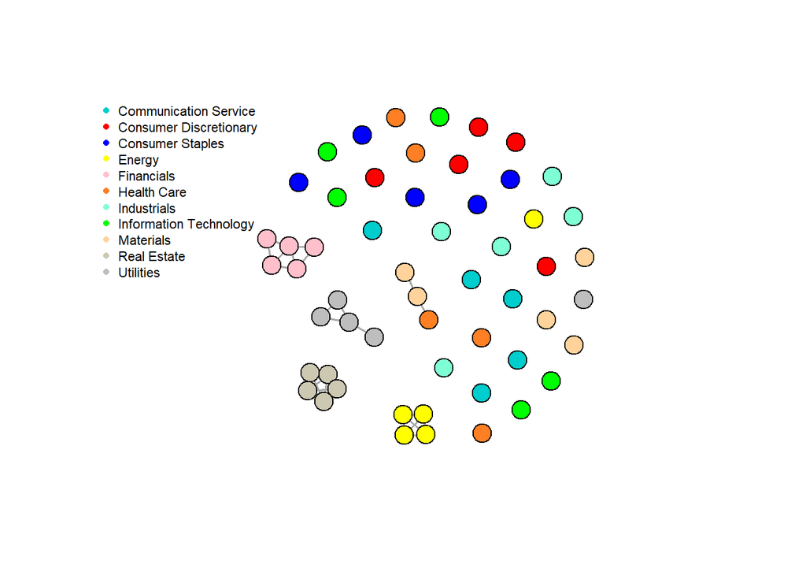

```r
plot(gr, edge.arrow.size = 5, vertex.size = 12, vertex.label = NA, vertex.label.dist = 2,  edge.width = 1.5)
legend(x = "topleft", GICS_sec, col = color_vec, pch = 16, bty = "n", cex = 0.7)
```

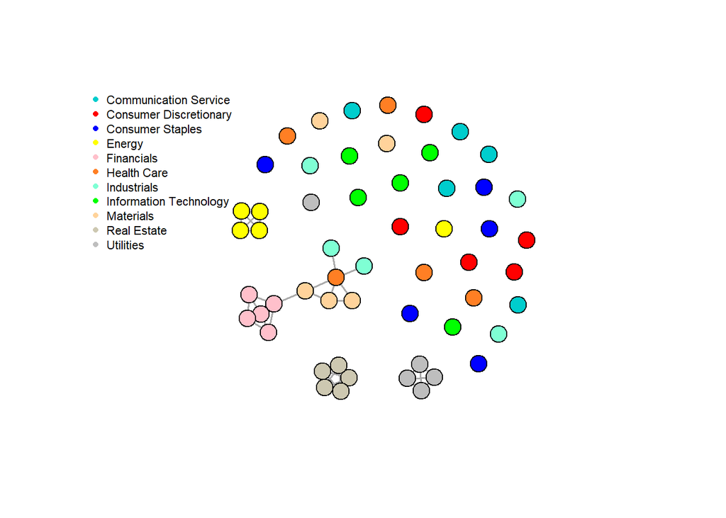

```r
plot(gr1, edge.arrow.size = 5, vertex.size = 12, vertex.label = NA, vertex.label.dist = 2,  edge.width = 1.5)
legend(x = "topleft", GICS_sec, col = color_vec, pch = 16, bty = "n", cex = 0.7)
```

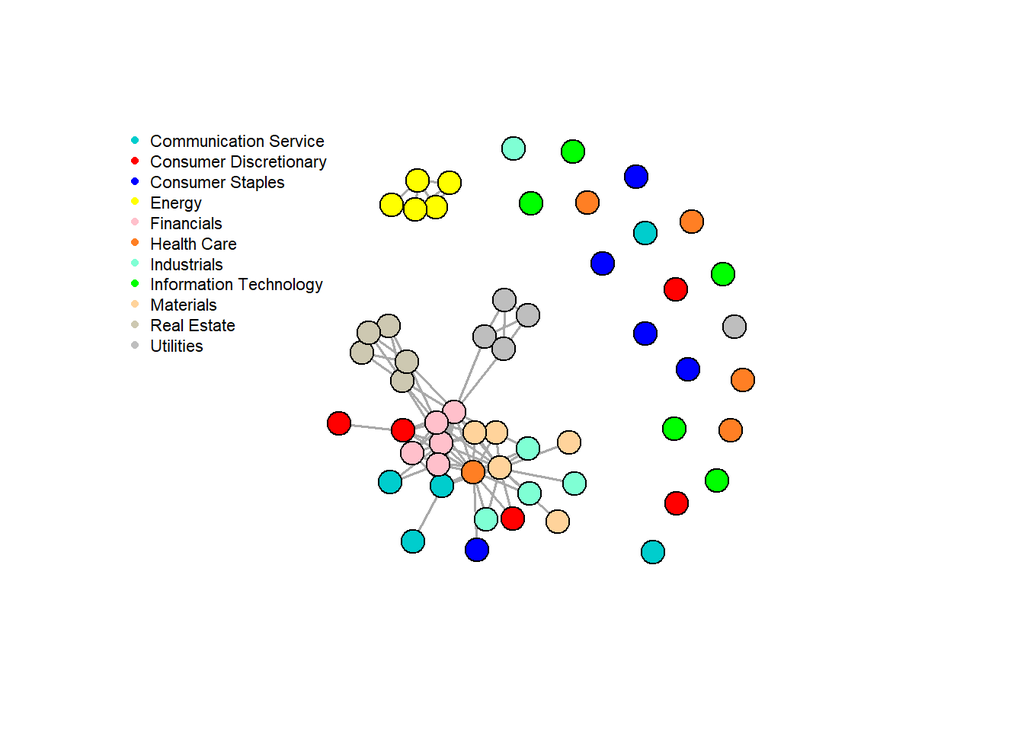

```r
plot(gr2, edge.arrow.size = 5, vertex.size = 12, vertex.label = NA, vertex.label.dist = 2,  edge.width = 1.5)
legend(x = "topleft", GICS_sec, col = color_vec, pch = 16, bty = "n", cex = 0.7)
```

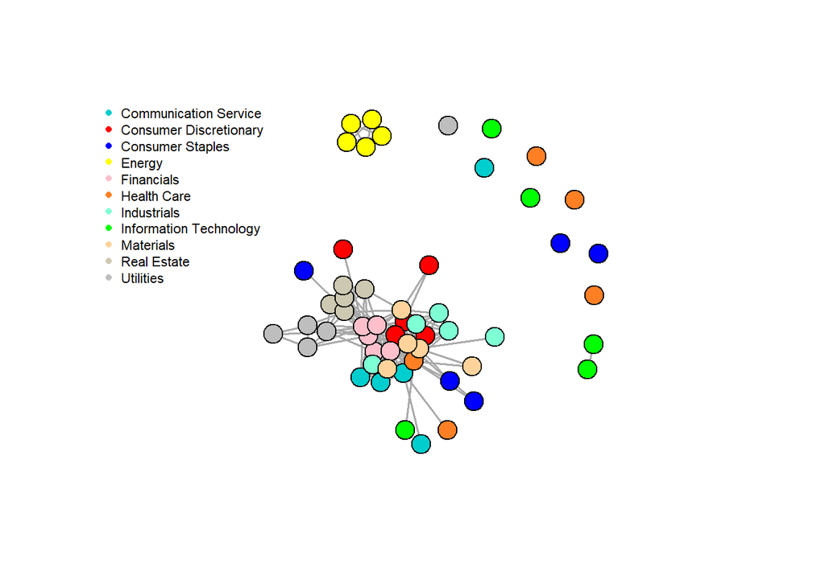

```r
plot(gr3, edge.arrow.size = 5, vertex.size = 12, vertex.label = NA, vertex.label.dist = 2,  edge.width = 1.5)
legend(x = "topleft", GICS_sec, col = color_vec, pch = 16, bty = "n", cex = 0.7)
```

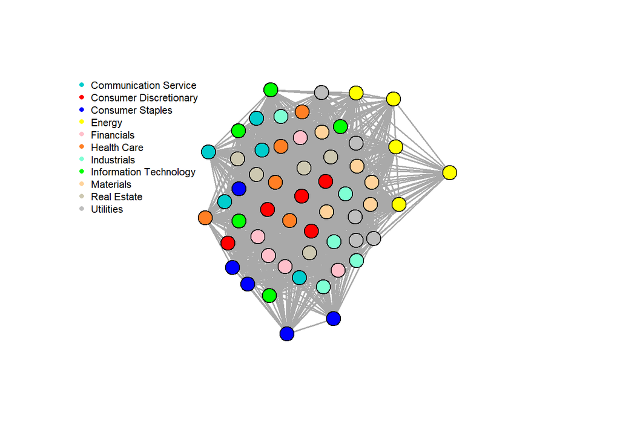

```r
plot(gr4, edge.arrow.size = 5, vertex.size = 12, vertex.label = NA, vertex.label.dist = 2,  edge.width = 1.5)
legend(x = "topleft", GICS_sec, col = color_vec, pch = 16, bty = "n", cex = 0.7)
```

As we can see from the plot with $\epsilon = 0.35$ some clusters are shown as well as some isolated nodes. In particular Energy, Financial and Utilities cluster together so we can deduce that the stocks inside these sectors follow the same trend in changing price.

With the decrease of $\epsilon$ value more correlations are shown: the correlations mentioned above are intensified. Furthermore correlations occur between different sectors: Communication service, Materials and Real estate cluster with each other and with the previous ones.

In general the plots show that sectors such as Consumer Discretionary, Consumer Staples, Health Care and Information Technology have isolated nodes.

## Distance correlation

```r
a <- Sys.time()
p_matr <- matrix(NA, nrow = 55, ncol = 55)
for (i in 1:55){
  for (j in 1:55){
    if (j >= i){
      dcov_test <- dcov.test(X_hat[, i], X_hat[, j], index = 0.001, R = 300)
      p <- dcov_test$p.value
      p_matr[i,j] <- p
    }
    else {
      p_matr[i,j] <- p_matr[j,i]
       }
    }
  }


b <- Sys.time()
print(b-a)
```

```
## Time difference of 33.07767 mins
```

We take $\alpha_1 = 0.05$ and then, we calculate a new value of $\alpha$ with the Bonferroni correction: $\alpha_2 = \frac{\alpha_1}{ \frac{55*54}{2}}$, where the denominator is the number of possible combinations between two firms.

```r
alpha1 <- 0.05
alpha2 <- 0.05/(55*54/2)
```

```r
adj_matr_cov <- matrix(0, nrow = 55, ncol = 55)

for (i in 1:55){
  for (j in 1:55){
    if (p_matr[i,j] < alpha1) {
      adj_matr_cov[i,j] <- 1
      adj_matr_cov[j,i] <- 1
    }
  }
}
```

This first graph shows that there are non-linear correlations: - The graph is connected - Firms from the same sector tend to cluster together again - It’s also shown that there are no more isolated nodes

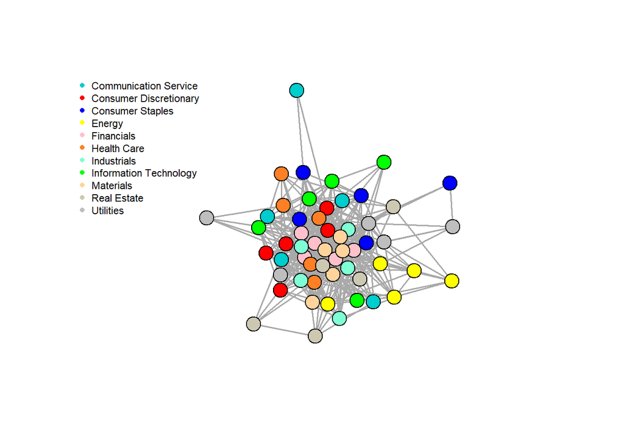

```r
gr_cov <- drawing_graph(adj_matr_cov)
V(gr_cov)$color = rep(color_vec, each = 5)


plot(gr_cov, edge.arrow.size = 5, vertex.size = 12, vertex.label = NA, vertex.label.dist = 2,  edge.width = 1.5)
legend(x = "topleft", GICS_sec, col = color_vec, pch = 16, bty = "n", cex = 0.7)
```

We expect that the Bonferroni correction is a really tight bound.

```r
adj_matr_cov2 <- matrix(0, nrow = 55, ncol = 55)

for (i in 1:55){
  for (j in 1:55){
    if (p_matr[i,j] < alpha2) {
      adj_matr_cov2[i,j] <- 1
      adj_matr_cov2[j,i] <- 1
    }
  }
}
```

As we expected the nodes are all isolated.

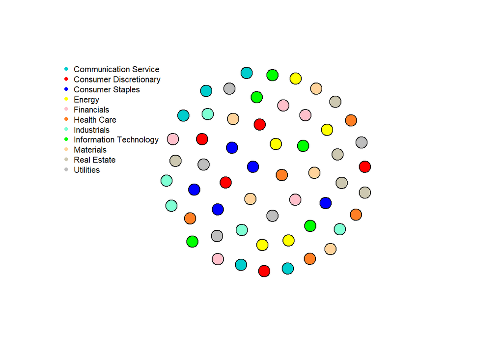

```r
gr_cov2 <- drawing_graph(adj_matr_cov2)
V(gr_cov2)$color = rep(color_vec, each = 5)


plot(gr_cov2, edge.arrow.size = 5, vertex.size = 12, vertex.label = NA, vertex.label.dist = 2,  edge.width = 1.5)
legend(x = "topleft", GICS_sec, col = color_vec, pch = 16, bty = "n", cex = 0.7)
```

## Repeating the analysis for the period 2013-2018

Here we want to repeat the analysis for the period after the financial crisis for the same firms already considered.

```r
require(tseries, quietly = TRUE)

firm_vector2 <- c()

invisible(capture.output (for (firm2 in colnames(X_hat)) try({

  hist_quote = suppressWarnings(get.hist.quote(instrument = firm2, start = "2013-01-01",
                                       end = "2018-01-01", quote = c("Open", "Close"),
                                       provider = "yahoo", drop = TRUE))
  # creating the new variable
  hist_quote$trfm_price = diff(log(hist_quote$Close))
  # and giving it a name
  assign(firm2, hist_quote$trfm_price[-1,])
  firm_vector2 <- c(firm_vector2, firm2)

})))
```

```r
merging2 <- lapply(firm_vector2, get)
merge2  = do.call('merge', merging2)
names(merge2) = firm_vector2
# we remove the columns with some NA values
merge2 <- merge2[ ,colSums(is.na(merge2)) == 0]
```

```r
symbols <- samp_symbols$Symbol

X_hat2 <- merge2[, symbols]
```

## Computing correlation matrix

```r
R_hat2 = matrix(NA, nrow = 55, ncol = 55)

R_hat2 = generate_corr_matr(X_hat2, R_hat2)
```

## Bootstrap procedure

```r
num_cores <- detectCores()

cl <- makeCluster(num_cores)

registerDoParallel(cl)

a <- Sys.time()

B = 1000 # number of replicates

delta_P2 = NULL

delta_P2 <- foreach(b = 1 : B, .combine=c) %dopar% {

  X_star2 <- matrix(NA, nrow = 1258, ncol = 55)

  idx = sample(1:1258, replace = TRUE)

  R_star2 =  matrix(NA, nrow = 55, ncol = 55 )

  for (i in 1:length(X_hat2[,1])){

      X_star2[i,] = X_hat2[idx[i],]

  }

  R_star2 = generate_corr_matr(X_star2, R_star2)

  sqrt(1258) * max(abs(R_star2 - R_hat2))

}

stopCluster(cl)
b <- Sys.time()

print(b-a)
```

```
## Time difference of 1.781071 secs
```

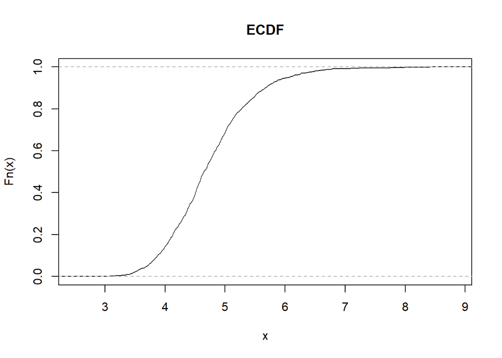

```r
F_hat_P2 = ecdf(delta_P2)

plot(F_hat_P2, main = "ECDF")
```

```r
alpha = 0.05
inv2 <- inverse(F_hat_P2, 0, 25718774)
t_alpha2 <- inv(1-alpha)
t_alpha2
```

```
## [1] 5.589204
```

```r
# adjacency matrix
new_cor_matr2  <- matrix(0, nrow = 55, ncol = 55)

generate_adj_matr2 = function(R_hat2, t_alpha2, epsilon){
  for (i in 1 : 55){
  for (j in 1 : 55){
    low2 <- R_hat2[i,j] - t_alpha2/sqrt(1258)
    up2 <- R_hat2[i,j] + t_alpha2/sqrt(1258)

    if ((-epsilon <= low2) & (epsilon <= low2)){

       new_cor_matr2[i,j] <- 1
       new_cor_matr2[j,i] <- 1

    }

    if ((-epsilon >= up2) & (epsilon >= up2)){

       new_cor_matr2[i,j] <- 1
       new_cor_matr2[j,i] <- 1
    }
  }


  }
  return(new_cor_matr2)
}


adj_matr_ <- generate_adj_matr2(R_hat2, t_alpha2, 0.35)
adj_matr_1 <- generate_adj_matr2(R_hat2, t_alpha2, 0.3)
adj_matr_2 <- generate_adj_matr2(R_hat2, t_alpha2, 0.25)
adj_matr_3 <- generate_adj_matr2(R_hat2, t_alpha2, 0.2)
adj_matr_4 <- generate_adj_matr2(R_hat2, t_alpha2, 0)
```

```r
gr_ <- drawing_graph(adj_matr_)
V(gr_)$color = rep(color_vec, each = 5)

gr_1 <- drawing_graph(adj_matr_1)
V(gr_1)$color = rep(color_vec, each = 5)

gr_2 <- drawing_graph(adj_matr_2)
V(gr_2)$color = rep(color_vec, each = 5)

gr_3 <- drawing_graph(adj_matr_3)
V(gr_3)$color = rep(color_vec, each = 5)

gr_4 <- drawing_graph(adj_matr_4)
V(gr_4)$color = rep(color_vec, each = 5)

par(c(5, 1))
```

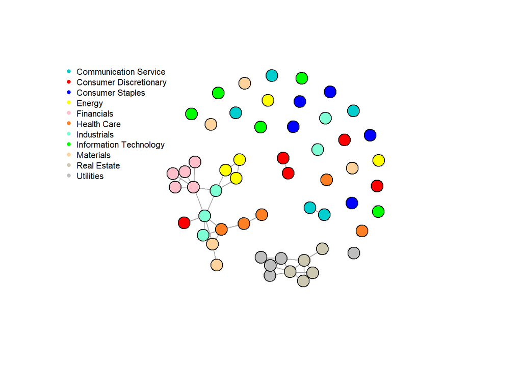

```r
plot(gr_, edge.arrow.size = 5, vertex.size = 12, vertex.label = NA, vertex.label.dist = 2)
legend(x = "topleft", GICS_sec, col = color_vec, pch = 16, bty = "n", cex = 0.7)
```

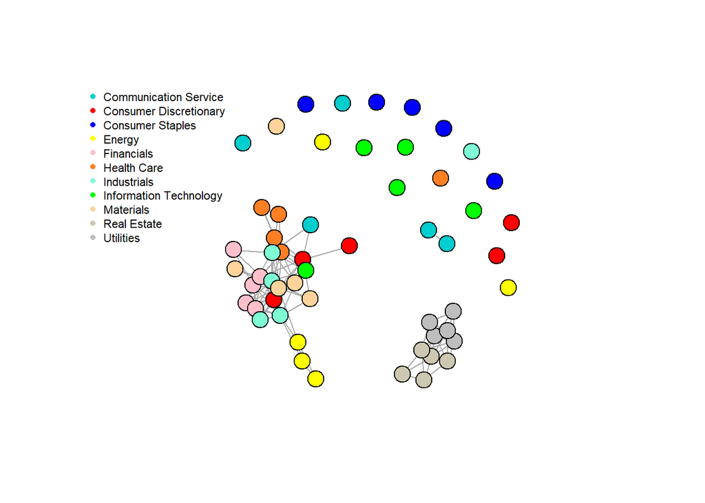

```r
plot(gr_1, edge.arrow.size = 5, vertex.size = 12, vertex.label = NA, vertex.label.dist = 2)
legend(x = "topleft", GICS_sec, col = color_vec, pch = 16, bty = "n", cex = 0.7)
```

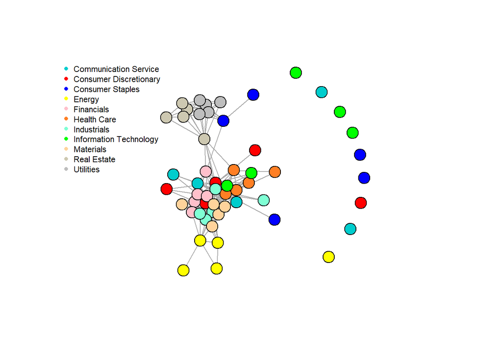

```r
plot(gr_2, edge.arrow.size = 5, vertex.size = 12, vertex.label = NA, vertex.label.dist = 2)
legend(x = "topleft", GICS_sec, col = color_vec, pch = 16, bty = "n", cex = 0.7)
```

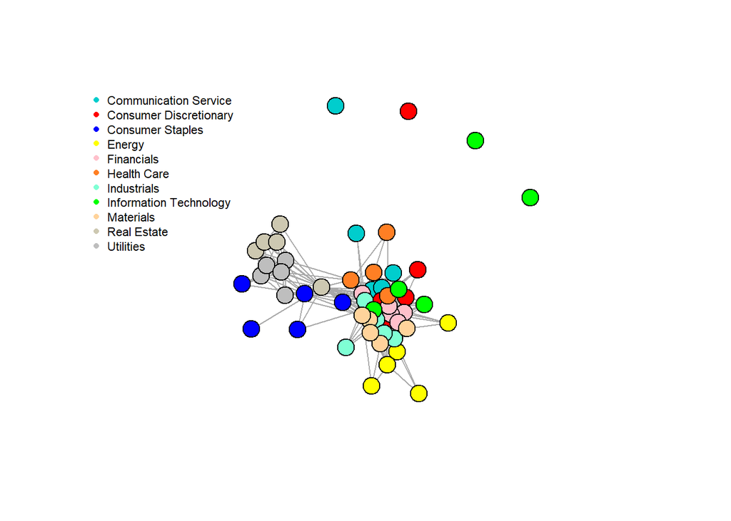

```r
plot(gr_3, edge.arrow.size = 5, vertex.size = 12, vertex.label = NA, vertex.label.dist = 2)
legend(x = "topleft", GICS_sec, col = color_vec, pch = 16, bty = "n", cex = 0.7)
```

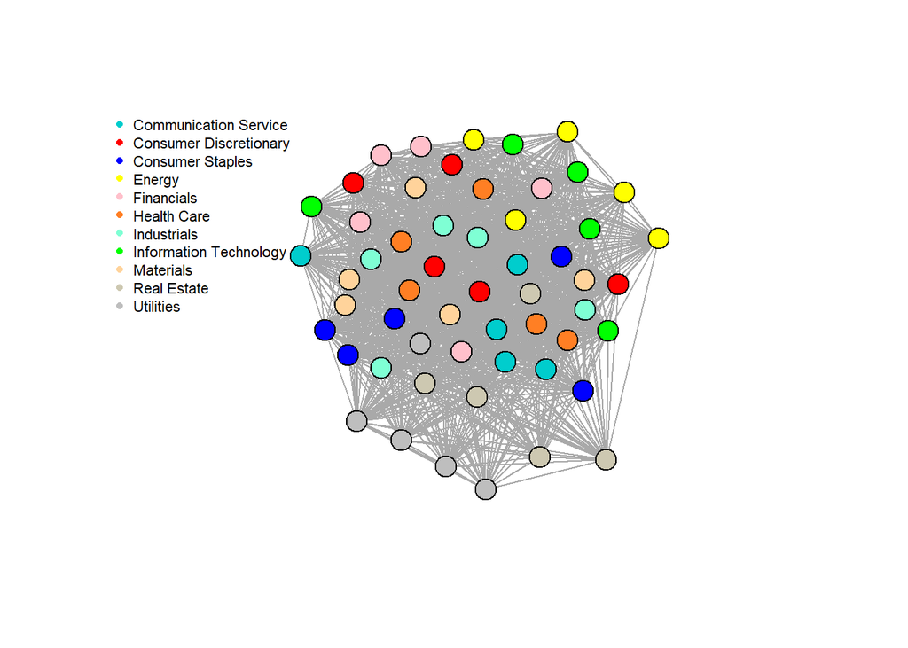

```r
plot(gr_4, edge.arrow.size = 5, vertex.size = 12, vertex.label = NA, vertex.label.dist = 2)
legend(x = "topleft", GICS_sec, col = color_vec, pch = 16, bty = "n", cex = 0.7)
```

The biggest difference we notice between the two time windows is that there are more correlations among different sectors using high values of $\epsilon$ ($0.35$, $0.3$). Furthermore we can see that sectors such as Energy and Information Technology didn’t follow the trends of the other sectors in the first period taken into account, but after the financial crisis they cluster with other firms of different branches.

```r
# distance covariance test
a <- Sys.time()
p_matr_new <- matrix(NA, nrow = 55, ncol = 55)
for (i in 1:55){
  for (j in 1:55){
    if (j >= i){
      dcov_test <- dcov.test(X_hat[, i], X_hat[, j], index = 0.001, R = 300)
      p <- dcov_test$p.value
      p_matr_new[i,j] <- p
    }
    else {
      p_matr_new[i,j] <- p_matr_new[j,i]
       }
    }
  }


b <- Sys.time()
print(b-a)
```

```
## Time difference of 33.21731 mins
```

```r
alpha1 <- 0.05
alpha2 <- 0.05/(55*54/2)
```

```r
adj_matr_cov3 <- matrix(0, nrow = 55, ncol = 55)

for (i in 1:55){
  for (j in 1:55){
    if (p_matr_new[i,j] < alpha1) {
      adj_matr_cov3[i,j] <- 1
      adj_matr_cov3[j,i] <- 1
    }
  }
}
```

In this case we have the same result: the first graph shows non-linear correlations, but with the Bonferroni correction the bound is too tight and the nodes are all isolated.

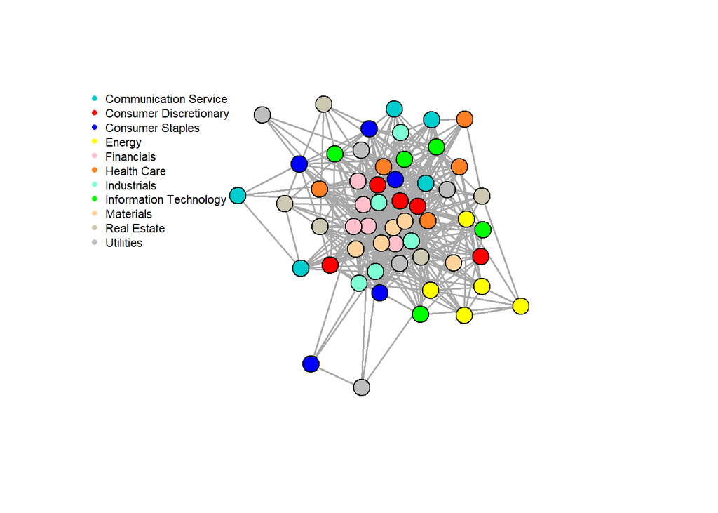

```r
gr_cov3 <- drawing_graph(adj_matr_cov3)
V(gr_cov3)$color = rep(color_vec, each = 5)


plot(gr_cov3, edge.arrow.size = 5, vertex.size = 12, vertex.label = NA, vertex.label.dist = 2,  edge.width = 1.5)
legend(x = "topleft", GICS_sec, col = color_vec, pch = 16, bty = "n", cex = 0.7)
```

```r
adj_matr_cov4 <- matrix(0, nrow = 55, ncol = 55)

for (i in 1:55){
  for (j in 1:55){
    if (p_matr_new[i,j] < alpha2) {
      adj_matr_cov4[i,j] <- 1
      adj_matr_cov4[j,i] <- 1
    }
  }
}
```

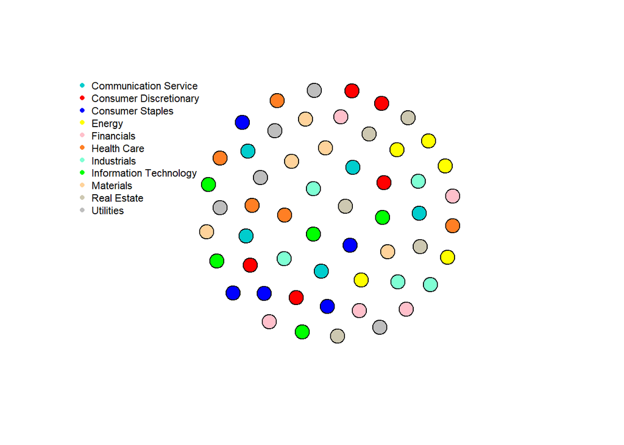

```r
gr_cov4 <- drawing_graph(adj_matr_cov4)
V(gr_cov4)$color = rep(color_vec, each = 5)


plot(gr_cov4, edge.arrow.size = 5, vertex.size = 12, vertex.label = NA, vertex.label.dist = 2,  edge.width = 1.5)
legend(x = "topleft", GICS_sec, col = color_vec, pch = 16, bty = "n", cex = 0.7)
```

### Collaboration with:

- Giorgio Zannini Quirini and Daniele Sanna
- Maria Luisa Croci and Valerio Antonini